# Darren’s Friends & Followers

S.Mckinnon

Jan 2017

### *Background*

As I waited for history to build up before I could complete the analysis of Darren Abbruzzese’s Twitter feed, I started to look at his Friends and [Followers](https://www.lifewire.com/a-guide-to-followers-on-twitter-2655405).

This Document is the result of that work. It should be seen as a companion piece to the main Twitter Analysis work, as it re-uses much of the same data and methods.

### *Packages Used*

To do the Data wrangling we have a few key packages; [Stringr](https://cran.r-project.org/web/packages/stringr/vignettes/stringr.html), [reshape2](https://cran.r-project.org/web/packages/reshape2/reshape2.pdf), [plyr](https://cran.r-project.org/web/packages/plyr/plyr.pdf) & [dplyr](https://cran.rstudio.com/web/packages/dplyr/vignettes/introduction.html).  
We are also dealing with dates/time stamps so [lubridate](https://cran.r-project.org/web/packages/lubridate/lubridate.pdf) will also help.

To Graph the data [ggplot2](http://ggplot2.org/), [ggrepel](https://cran.r-project.org/web/packages/ggrepel/vignettes/ggrepel.html) and [RColorBrewer](https://cran.r-project.org/web/packages/RColorBrewer/RColorBrewer.pdf) will be key.

To source the required user location details [ggmap](https://cran.r-project.org/web/packages/ggmap/ggmap.pdf) is used.

For the world map, I have used [maps](https://cran.r-project.org/web/packages/maps/maps.pdf), and [gridExtra](https://cran.r-project.org/web/packages/gridExtra/index.html) for the layout

```r
# Data Wrangling
library(stringr)
library(dplyr)
library(plyr)
library(lubridate)
library(reshape2)
# Graphing
library(ggplot2)
library(ggrepel)
library(RColorBrewer)
# Location details
library(ggmap)
# World Map
library(maps)
library(gridExtra)
```

### *Get the Data*

The Twitter scrapper was covered in the **Twitter Analysis**, so I wont cover it again here.

For this work I also wanted the details of the individuals who make up Darren’s twitter network, including tweet counts and their network details. I created a loop function that would query each user’s details from source and provide this.

```r
# load in a list of the screen names of Darren's followers
DF_friends_DA <- following$screenName

# a loop that work through the list, returns key data, builds a results file and then wrotes it out
for (i in 1:length(DF_follow_DA)) {
  # create the empty dat frame used for the results file
  if (i==1) {res_df <- data.frame(txt_nam = character(),
                                  cnt_follow = numeric(),
                                 cnt_friend = numeric(),
                                  cnt_tweet = numeric())}

  # builds the result line, cell by cell.
  x_txt <- DF_follow_DA[i]
  # calls Twitter to get that user's followers
  x_FO <- getUser(DF_follow_DA[i])$followersCount
  # calls Twitter to get that user's friends
  x_FR <- getUser(DF_follow_DA[i])$friendsCount
  # call Twitter to get that user's tweet count
    x_TW <- getUser(DF_friends_DA[i])$statusesCount
  # creates that user's results file line.
    # *.data.frame used to ensure data type is held
  x_df <- as.data.frame(cbind.data.frame(txt_nam = x_txt,
                              cnt_follow =x_FO,
                              cnt_friend =x_FR,
                              cnt_tweet=x_TW))
  # appends that users detail to the results file
  res_df <- rbind.data.frame(res_df, x_df)

  # if the end of the list is reached
  if(i==length(DF_follow_DA)) {
    # add in ANZ flag, based upon that Users account description
    res_df <- cbind.data.frame(res_df,
                               ANZ=grepl('anz', followers$description,
                                         ignore.case=TRUE))
    # addin Darren's detail for graphing purposes
    DA_txt <- getUser(userName)$screenName
    DA_FO <- getUser(userName)$followersCount
    DA_FR <- getUser(userName)$friendsCount
    DA_TW <- getUser(userName)$statusesCount
    # append it to the results set
    res_df <- rbind.data.frame(res_df, as.data.frame(cbind.data.frame(txt_nam = DA_txt,
                                                cnt_follow = DA_FO,
                                                cnt_friend = DA_FR,
                                                cnt_tweet = DA_TW,
                                                ANZ="ZDA")))


    # write out the result file locally, including a date reference
    write.table(res_df, file=paste0("./Networks/followers_", userName,
                                    substr(date(),0,10), ".txt"),
                sep=",", row.names = FALSE)
    # user message
    print("job done") }

}
```

This provided summary details of Darren’s twitter network.

I was also interested in their location. Based upon that Users Twitter Location, I could use the Google R Package [ggmap](https://cran.r-project.org/web/packages/ggmap/ggmap.pdf) to get the Longitude and Latitude. This would enable using a map as a graphic.

This code calls the Google API on a per user basis, which can take some time. So I will only include the key code snippets here.

```r
# set the twitter account for scrapping
  tmp = getUser('@abbruzzd')
# call twitter to get the followers listing
  followers=twListToDF(tmp$getFollowers())
# set all of the locations to lower text, making the matching easier
  followersLocation = tolower(followers$location)
# correct for the US Melbourne, returned by default by the Google API.
  followersLocation <- replace(followersLocation,
                               followersLocation=="melbourne", "melbourne, Australia")
# call the Google API to provide the lat/lon
  tst_following <- cbind(followingLocation, geocode(followingLocation))
# join to a refernce table provding the continent details of that location
   tst_following <- tst_following %>% left_join(Con_CSV, c("followingLocation"="V1"))

# the resulting file is then written out to a local file
```

For obvious reasons, this analysis will just load from files created by this scrapper.

### *A Followers Map*

First lets map Darren’s followers to get a sense of the span of influence.

- The Code used to center the map on Australia and re-calculate the locations is complex and long, so I wont display it here. Its largely a copy/paste from the work of Claudia Engel, I would encourage people to visit his blog to get a better understanding.

Once all of the re-calculations have been done, we can map the details.

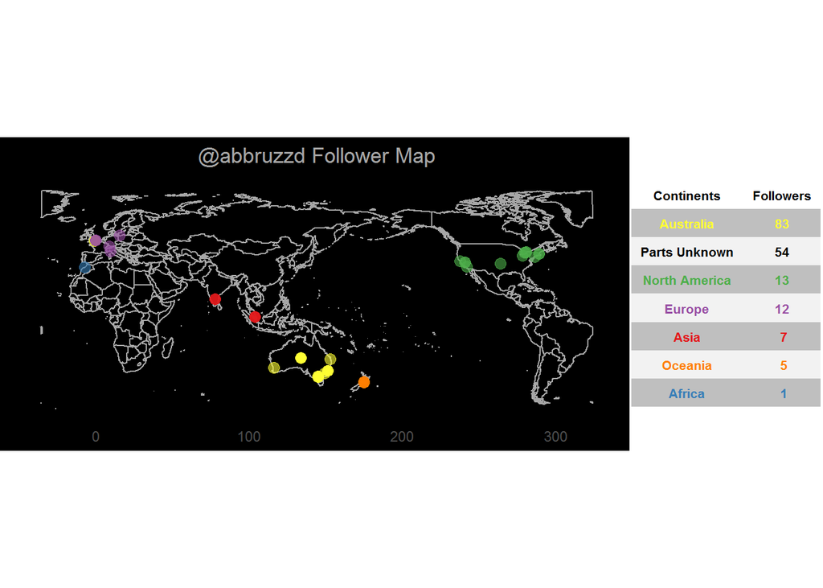

```r
# plotting library(ggplot2)
# create the global map object
worldmap = ggplot(aes(x = long.recenter, y = lat,
                      col="#191919"), data = worldmap.cp) +
  geom_polygon(aes(group = group.regroup), fill="black", colour = "grey65") +
  scale_y_continuous(limits = c(-60, 85)) +
  ggtitle(paste(userName," Follower Map",sep=""))+
  coord_equal() +
  theme_bw() +
  theme(
    legend.position = "none",
    panel.grid.major = element_blank(),
    panel.grid.minor = element_blank(),
    axis.title.x = element_blank(),
    axis.title.y = element_blank(),
    plot.title = element_text(colour = "grey65", hjust=0.5),
    axis.text.y = element_blank(),
    axis.ticks = element_blank() ,
    panel.border = element_rect(colour = "black"),
    panel.background = element_rect(fill = "black", colour = "black"),
    plot.background = element_rect(fill = "black", colour = "black")
  )

# use colour brewer for better colour range
# Set up the ploting colors
cols = brewer.pal(8,"Set1")
cols=cols[-7]

#attach the colours to each cont
map_dots = map_followers %>% filter(V2!="Parts Unknown") %>%
  select(lon.recent, lat, lon, V2 ) %>% mutate(dot_col = ifelse(V2=="Asia", cols[1],
                                                            (ifelse(V2=="Africa",cols[2],
                                                                    (ifelse(V2=="North America",cols[3],
                                                                            (ifelse(V2=="Europe",cols[4],
                                                                                    ( ifelse(V2=="Australia",
                                                                                             cols[6], cols[5]))))))))))
#make continent a factor for colouring of graph
map_dots$V2 <- as.factor(map_dots$V2)

#create the legend detail, including the NA's cont
# create the legend table
leg_tab <- melt(table(sou_followers$V2))
colnames(leg_tab) <- c("Continents", "Followers")
#add in cont colours
map_col <- map_dots %>% select(V2, dot_col) %>% distinct(V2, dot_col)
leg_tab <- leg_tab %>% left_join(map_col, c("Continents"="V2"))
#update unknown to black
leg_tab[7,3] ="#000000"
#sort for displa
leg_tab <- leg_tab %>% arrange(desc(Followers))

# load on the followers data as points, using the continent coloring
worldmap1 = worldmap +
  geom_point(data = map_dots, aes(x=lon.recent, y=lat, color=V2),
             pch = 19, size = 3, alpha = .6) +
  scale_colour_manual(name="",
                      values = c("Europe"= "#984EA3",
                                 "North America"="#4DAF4A",
                                 "Australia" ="#FFFF33",
                                 "Africa" = "#377EB8",
                                 "Asia"="#E41A1C",
                                 "Oceania"="#FF7F00"))

#load grid extra for to add on the legend as a summary table
grid.arrange( worldmap1,
              tableGrob(leg_tab[,1:2],
                        theme = ttheme_minimal(base_size = 8,
                                               base_colour = leg_tab[,3],
                                               core=list(bg_params = list(fill = c("grey75", "grey95"), col=NA),
                                                         fg_params=list(fontface="bold")),
                                               colhead=list(fg_params=list(col="black"))),
                        #remove row id's
                        row = NULL),
              ncol=2,
              widths=c(2.6, 0.8),
              clip=FALSE)
```

The First thing to note is the large number of false or unknown locations, which are classified as **Parts Unknown**.

- Either the Google API cant find the lon/lat or the user simply hasn’t entered this detail into their Twitter profile.

Unsurprisingly, Darren has the strongest following in Australia and then a smattering across major locations in the US and Europe. While its geographically diverse, its also sparse.

### *Friends and Followers*

Twitter is made up of both Friends and Followers. I wanted to see how Darren stood within his own network. First who he is following.

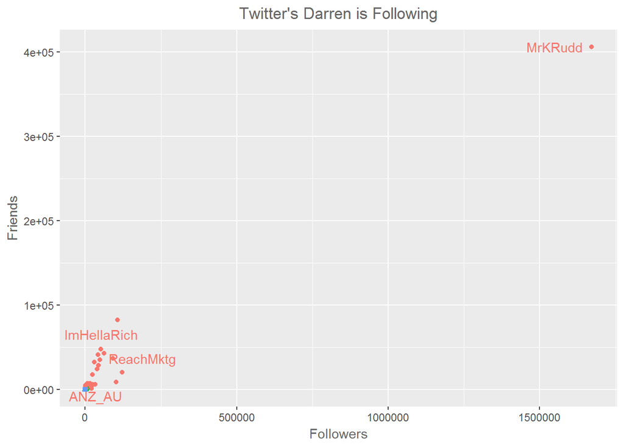

```r
ggplot(data=fol_txt, aes(x=cnt_follow, y=cnt_friend)) +
    ggtitle("Twitter's Darren is Following") +
    xlab("Followers") +
    ylab("Friends") +
   geom_point(aes(shape=ANZ, colour=ANZ)) +
  # limited data labels
    geom_text_repel( data=filter(fol_txt, (cnt_follow>=100000 | cnt_friend >= 100000)),
                     aes(
                      color = factor(ANZ),
                       label = txt_nam
                     ),
                     point.padding = unit(0.25, "lines"),
                     box.padding = unit(0.25, "lines"),
                     nudge_y = 0.1
    ) +
    theme(
      legend.position = "none",
      axis.title.x = element_text(colour = "grey40"),
      axis.title.y = element_text(colour = "grey40"),
      plot.title = element_text(colour = "grey40", hjust=0.5)
    )
```

With such outliers in the data, its hard to understand where Darren falls in all this. So I decided to scale and remove the outliers.

```r
# scale the data
  z <- scale(fol_txt[,2:3])
#classify based upon the scaled mean
  score <- apply(z, 1, mean)
# classify the data based upon spread
  y <- quantile(score, c(.8,.6,.4,.2))
  fol_txt$Q[score >=y[1]] <- "A"
  fol_txt$Q[score < y[1] & score >= y[2]] <- "B"
  fol_txt$Q[score <y[2] & score >= y[3]] <- "C"
  fol_txt$Q[score < y[3] & score >= y[4]] <- "D"
  fol_txt$Q[score < y[4]] <- "E"

#subset the data, removing the top and bottom classifications
  sub_fol_txt <- subset(fol_txt, Q %in% c("B", "C", "D"))

#update titles used in the graph
  sub_fol_txt$lab <- ifelse(sub_fol_txt$cnt_friend>=2000, sub_fol_txt$txt_nam,
                            (ifelse(sub_fol_txt$cnt_follow>=2000, sub_fol_txt$txt_nam,
                                    (ifelse(sub_fol_txt$txt_nam=="abbruzzd","abbruzzd", "")))))
```

Now with a limited data set, we can re-visit the graph. For reference, ANZ accounts have been coloured.

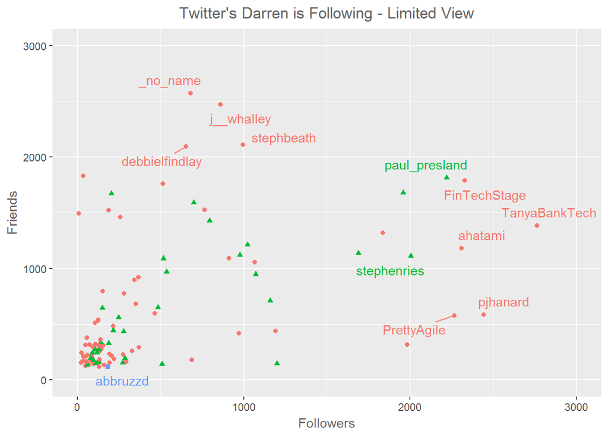

While this is a better view, even with these adjustments Darren still struggles to stand out.

Ok, perhaps the story is different for the user’s Darren follows?

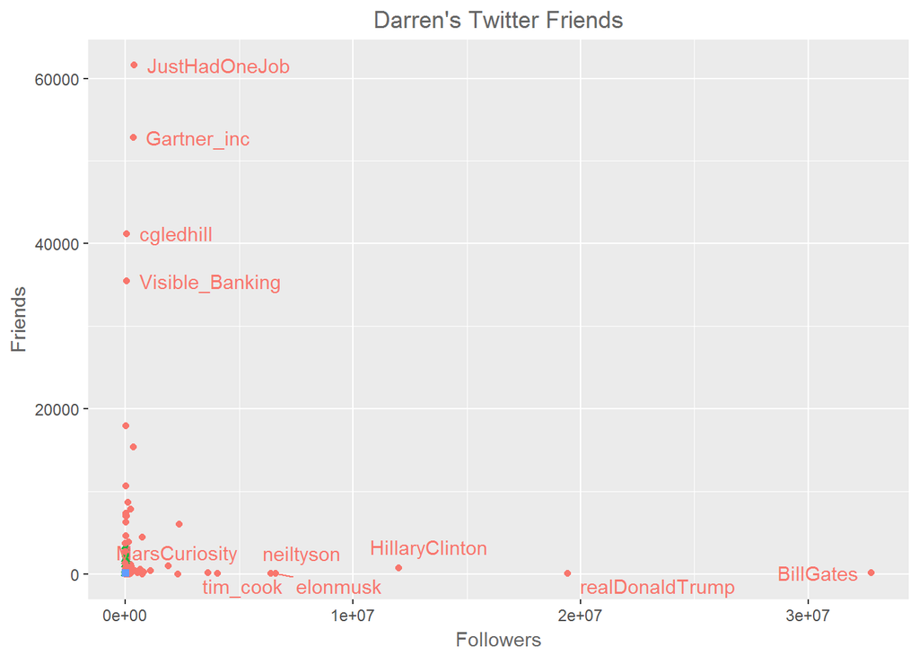

This time the skew is even worse. So lets try just the ANZ accounts with a linear regression.

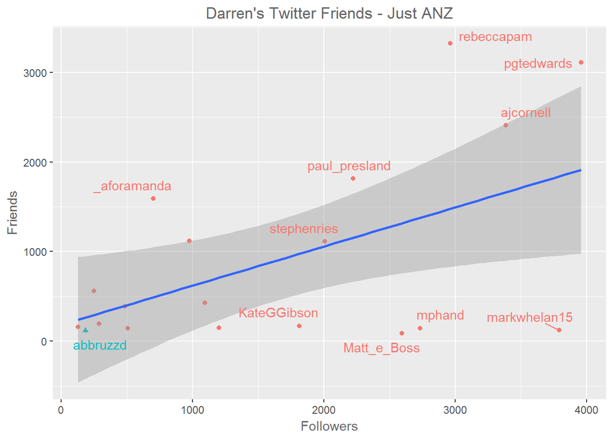

### *Content vs Friends and Followers*

I wanted to understand if there is a relationship between content and network.

Once again, I am using the ANZ only data sets. First the Twitter account’s Darren is following.

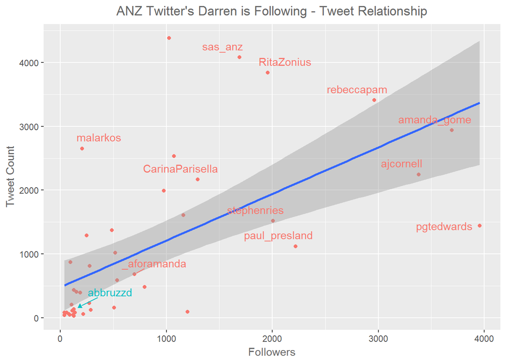

```r
#subset to just ANZ
  ANZ_fol_txt <- subset(fol_txt, (ANZ==TRUE | txt_nam=="abbruzzd"))
  ANZ_fol_txt$lab <- ifelse(ANZ_fol_txt$cnt_friend>=1500, ANZ_fol_txt$txt_nam,
                            (ifelse(ANZ_fol_txt$cnt_follow>=1500, ANZ_fol_txt$txt_nam,
                                    (ifelse(ANZ_fol_txt$txt_nam=="abbruzzd","abbruzzd", "")))))

  # graph followers vs. Tweet count
  ggplot(data=ANZ_fol_txt, aes(x=cnt_follow, y=cnt_tweet)) +
    ggtitle("ANZ Twitter's Darren is Following - Tweet Relationship") +
    xlab("Followers") +
    ylab("Tweet Count") +
    geom_point(aes(shape=ANZ, colour=ANZ)) +
    # addin Linear regression model
    geom_smooth(method='lm') +
    geom_text_repel( data=filter(ANZ_fol_txt, !is.na(lab)),
                     aes(
                       color = factor(ANZ),
                       label = lab
                     ),
                     point.padding = unit(0.25, "lines"),
                     box.padding = unit(0.25, "lines"),
                     nudge_y = 0.1
    ) +
    theme(
      legend.position = "none",
      axis.title.x = element_text(colour = "grey40"),
      axis.title.y = element_text(colour = "grey40"),
      plot.title = element_text(colour = "grey40", hjust=0.5)
    )
```

Next the Twitter account’s that are following Darren.

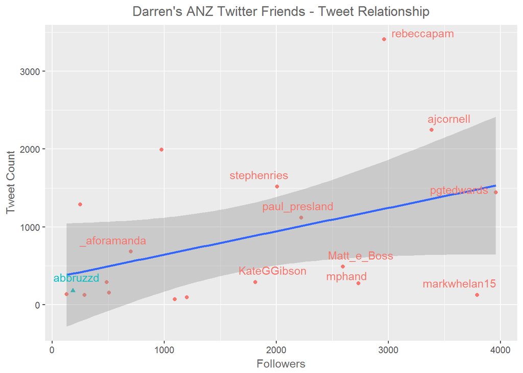

This data would suggest there is a more complex relationship between a twitter feed and the network it forms part of than can be represented by a simple linear regression. But that’s another piece of work.

#### *References*

This Analysis has used a large number of sources, including the forever helpful [Stackoverflow](http://stackoverflow.com/).

Some of the main references are;

- The original idea for this is [Jeff’s Leaks](http://biostat.jhsph.edu/~jleek/code/twitterMap.R).
- How to re-centre a map.
- How to get the [Legend](http://127.0.0.1:27758/library/gridExtra/doc/tableGrob.html) working on the world map.
- How to get a [stacked bar](http://stackoverflow.com/questions/19778612/change-color-for-two-geom-point-in-ggplot2) chart working in ggplot.

-**– end of document –**_